# DATA607 Assignment 6: Web APIs

Albert Gilharry

29 March 2018

## Intro

**We were tasked to choose one of the New York Times APIs, construct an interface in R to read in the JSON data, and transform it to an R dataframe.**

**I decided to use the Most Popular API. This API returns a list of New York Times Articles based on shares, emails, and views.**

## Load JSON Data into Data Frame

I will use to NYT API to get the most frequently shared (by email) articles over the last 30 days.

The NYT API returns a maximum of 20 articles per request.

We must paginate these request using the `offset` parameter.

We must also ensure that we do not exceed the rate limit of 5 requests per second.

```r
# load JSON data into data frame
url = paste0("https://api.nytimes.com/svc/mostpopular/v2/mostemailed/all-sections/30.json?api-key=", api_key)
articles <- fromJSON(url, flatten = TRUE) %>% data.frame()
pages <- floor(articles$num_results[1]/20)

for(i in 1:pages){
  print(paste0("Loading page ", i, " of ", pages, "." ))
  page <- fromJSON(paste0(url, "&offset=",i*20), flatten = TRUE) %>% data.frame()
  articles <- bind_rows(articles,page) # build data frame incrementally
  Sys.sleep(1) #Stay within usage rate limits
}
```

```
## [1] "Loading page 1 of 62."
## [1] "Loading page 2 of 62."
## [1] "Loading page 3 of 62."
## [1] "Loading page 4 of 62."
## [1] "Loading page 5 of 62."
## [1] "Loading page 6 of 62."
## [1] "Loading page 7 of 62."
## [1] "Loading page 8 of 62."
## [1] "Loading page 9 of 62."
## [1] "Loading page 10 of 62."
## [1] "Loading page 11 of 62."
## [1] "Loading page 12 of 62."
## [1] "Loading page 13 of 62."
## [1] "Loading page 14 of 62."
## [1] "Loading page 15 of 62."
```

[output cut: 47 more lines]

```r
# add row id to utilize less memory when transforming
articles <- rowid_to_column(articles,'id')
```

## Preview Resulting Data Table

```r
print(names(articles))
```

```
##  [1] "id"                     "status"
##  [3] "copyright"              "num_results"
##  [5] "results.url"            "results.count_type"
##  [7] "results.column"         "results.section"
##  [9] "results.byline"         "results.title"
## [11] "results.abstract"       "results.published_date"
## [13] "results.source"         "results.des_facet"
## [15] "results.org_facet"      "results.per_facet"
## [17] "results.geo_facet"      "results.media"
```

```r
datatable(head(select(articles, results.title, results.source, results.des_facet, results.published_date)), options = list(filter = FALSE))
```

|  | results.title | results.source | results.des_facet | results.published_date |
| --- | --- | --- | --- | --- |
| 1 | Remarkable Women We Overlooked in Our Obituaries | The New York Times | ['BIOGRAPHICAL INFORMATION', 'WOMEN AND GIRLS'] | 2018-03-08 |
| 2 | For Two Months, I Got My News From Print Newspapers. Heres What I Learned. | The New York Times | ['NEWS AND NEWS MEDIA', 'COMPUTERS AND THE INTERNET', 'NEWSPAPERS', 'SOCIAL MEDIA'] | 2018-03-07 |
| 3 | Extensive Data Shows Punishing Reach of Racism for Black Boys | The New York Times | ['INCOME INEQUALITY', 'RACE AND ETHNICITY', 'BLACKS', 'CHILDREN AND CHILDHOOD'] | 2018-03-19 |
| 4 | Should You Get a Cheaper Phone? Be Sure to Look Into the Camera | The New York Times | ['SMARTPHONES', 'ANDROID (OPERATING SYSTEM)'] | 2018-02-28 |
| 5 | The Best Makeup You Can Buy at the Drugstore | The New York Times | ['COSMETICS AND TOILETRIES', 'SKIN', 'DRUGSTORES'] | 2018-03-01 |
| 6 | The Pain of Loving Old Dogs | The New York Times | ['DOGS', 'PETS'] | 2018-02-25 |

## Tidy & Transform Data

I would like to do an exploration to find out the tags/keywords with the highest proportion of shares by email. The descriptive tags for each article is stored in a character vector with multiple elements in `results.des_facet`. The keywords will need to be separated and then placed in a long format to facilitate downstream analysis.

```r
keywords <- select(articles, `id`, `results.des_facet`)  %>%
  group_by(`id`) %>% summarize(keyword = paste(unlist( `results.des_facet` ),collapse = ","))  %>%
  cSplit("keyword", sep = ",", direction = "long")
```

## Preview Transformed Data

```r
datatable(keywords, options = list(filter = FALSE))
```

|  | id | keyword |
| --- | --- | --- |
| 1 | 1 | BIOGRAPHICAL INFORMATION |
| 2 | 1 | WOMEN AND GIRLS |
| 3 | 2 | NEWS AND NEWS MEDIA |
| 4 | 2 | COMPUTERS AND THE INTERNET |
| 5 | 2 | NEWSPAPERS |
| 6 | 2 | SOCIAL MEDIA |
| 7 | 3 | INCOME INEQUALITY |
| 8 | 3 | RACE AND ETHNICITY |
| 9 | 3 | BLACKS |
| 10 | 3 | CHILDREN AND CHILDHOOD |

[output cut: 3029 more lines]

## Visualization: Top 20 Email Shares by Keyword

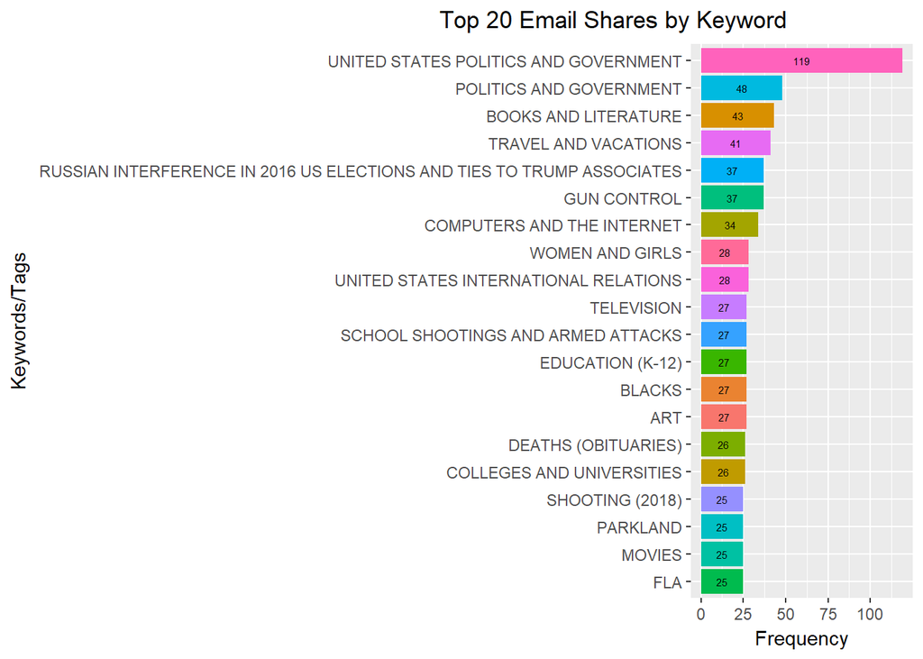

```r
  group_by(keywords, keyword) %>%
  summarize(count = n())  %>%
  arrange(desc(count)) %>%
  top_n(20,count) %>%
  ggplot(aes(x = reorder(keyword, count), y = count,  fill=keyword, label = count)) +
  geom_histogram( stat='identity', show.legend = F ) +
  geom_text(size = 2, position = position_stack(vjust = 0.5)) +
  coord_flip() +
  labs( title = "Top 20 Email Shares by Keyword", x = "Keywords/Tags", y = "Frequency" ) +
  theme(plot.title = element_text(hjust = 2))
```

## Conclusion

The results show that the top NYT Articles shared by email were dominated by politics. 3 of the top 20 tags were related to Gun violence. It would be great for more media houses to provide such an API service so that we can compare and contrast trending feeds across various sources.